# Optional tutorial: applying MOFA to integrate multi-omics data from the BeatAML study

Author

Affiliation

Junyan Lu

University Hospital Heidelberg, Germany

Published

February 1, 2024

# Introduction

In this optional tutorial, you are encouraged to apply MOFA, based on what you’ve learned in the main tutorial, to integrate and interpret a multi-omic dataset from the BeatAML study: https://www.cancer.gov/about-nci/organization/ccg/blog/2019/beataml. The datasets from BeatAML cohort are very similar to those from the CLL cohort. In this practical session, we will use the drug screen, mRNA expression and mutation data from this study. The pre-processed data can be found in the “processed” folder.

# Specific tasks

**Task 1: Format the pre-processed omics data and prepare input for MOFA.**. You have the freedom to choose your own ways of formatting the omics data, as long as they make statistical sense and follow the requirements of MOFA model. If you are not sure, please consult the trainers.

**Task 2: Setup and train MOFA model.** Don’t forget to choose an appropriate likelihood for each of the data modalities!

**Task 3: Visualise the MOFA training results.** You can use the pre-built functions within MOFA2 package or your own codes to explore the results of MOFA training. You are encouraged to answers questions like: How to get the factor scores for each sample? Are those factor scores correlate with each other? How much variance can each factor explain for each view?

**Task 4: Interpreting the MOFA training results.** Please use the pre-built functions within MOFA2 package or your own codes to answer the below questions:  
- How to identify interesting factors from MOFA results?  
- How to understanding the biology behind the MOFA factors?  
- How those results can be used for clinical or biological applications?

# Solutions

**We encourage you to attempt the tasks yourself before “peeking” at the solutions.**

## Load packages

```r
library(MOFA2)
library(DESeq2)
library(tidyverse)
```

## Load and preprocess data

### Gene expression matrix

Load expression matrix

```r
exprMat <- read_tsv("processed/rna_count_matrix.tsv.gz") %>%
  data.frame() %>% column_to_rownames("Gene_symbol") %>%
  as.matrix()
```

```r
keepGene <- rowMeans(exprMat) > 10
exprMat <- exprMat[keepGene,]
```

Variance stabilizing transformation

```r
exprMat.vst <- varianceStabilizingTransformation(exprMat, blind=TRUE)
```

Current dimensions

```r
dim(exprMat.vst)
```

```
[1] 19984   494
```

Only keep top 5000 most variable genes (optional)

```r
sds <- apply(exprMat.vst, 1, sd)
exprMat.filt <- exprMat.vst[order(sds, decreasing = TRUE)[1:5000],]
```

### Drug response

Load drug response as a table

```r
drugTab <- read_tsv("processed/drug_response_table.tsv")
```

Data structure

```r
head(drugTab)
```

```
# A tibble: 6 × 3
  inhibitor             lab_id         auc
  <chr>                 <chr>        <dbl>
1 17-AAG (Tanespimycin) AML_12_00211  226.
2 17-AAG (Tanespimycin) AML_12_00219  135.
3 17-AAG (Tanespimycin) AML_12_00258  165.
4 17-AAG (Tanespimycin) AML_12_00262  112.
5 17-AAG (Tanespimycin) AML_12_00268  227.
6 17-AAG (Tanespimycin) AML_12_00288  113.
```

Reshape to a matrix

```r
drugMat <- drugTab %>%
  pivot_wider(names_from = "lab_id", values_from = "auc") %>%
  data.frame() %>% column_to_rownames("inhibitor") %>%
  as.matrix()
```

Current dimension of the matrix

```r
dim(drugMat)
```

```
[1] 122 528
```

Remove drugs that have too many NA values (optional). Remove drugs that have been tested in less than 50% of the samples

```r
keepDrug <- rowSums(is.na(drugMat))/ncol(drugMat) < 0.5
drugMat.filt <- drugMat[keepDrug,]
```

Current dimension

```r
dim(drugMat.filt)
```

```
[1] 105 528
```

### Genetic variations

#### Load gene mutation table

```r
geneTab <- read_tsv("processed/gene_mutation_table.tsv")
geneTab
```

```
# A tibble: 4,138 × 3
   lab_id       gene     value
   <chr>        <chr>    <dbl>
 1 AML_09_00705 FLT3.ITD     1
 2 AML_09_00705 NPM1         1
 3 AML_09_00705 FLT3         0
 4 AML_09_00705 JAK2         0
 5 AML_09_00705 KIT          0
 6 AML_10_00136 FLT3.ITD     1
 7 AML_10_00136 NPM1         0
 8 AML_10_00136 CEBPA        0
 9 AML_10_00172 FLT3.ITD     1
10 AML_10_00172 NPM1         0
# … with 4,128 more rows
# ℹ Use `print(n = ...)` to see more rows
```

Reshape to a matrix

```r
geneMat <- geneTab %>%
  pivot_wider(names_from = "lab_id", values_from = "value") %>%
  data.frame() %>% column_to_rownames("gene") %>%
  as.matrix()
```

Current dimensions

```r
dim(geneMat)
```

```
[1]  15 671
```

There are quite some missing values (NA) in the data matrix. We will keep them, as MOFA should be able to deal with them.

```r
str(geneMat)
```

```
 num [1:15, 1:671] 1 1 0 0 0 NA NA NA NA NA ...
 - attr(*, "dimnames")=List of 2
  ..$ : chr [1:15] "FLT3.ITD" "NPM1" "FLT3" "JAK2" ...
  ..$ : chr [1:671] "AML_09_00705" "AML_10_00136" "AML_10_00172" "AML_10_00507" ...
```

## Prepare MOFA model

### Create MOFA object

Generate a long data frame

```r
AML_df <- bind_rows(
  drugMat.filt %>% as_tibble(rownames = "feature") %>%
    pivot_longer(-feature, names_to = "sample", values_to = "value") %>%
    mutate(view = "Drugs"),
  exprMat.filt %>% as_tibble(rownames = "feature") %>%
    pivot_longer(-feature, names_to = "sample", values_to = "value") %>%
    mutate(view = "mRNA"),
  geneMat %>% as_tibble(rownames = "feature") %>%
    pivot_longer(-feature, names_to = "sample", values_to = "value") %>%
    mutate(view = "Mutations"),
)
```

We would like to keep the samples that have at least two views (optional)

```r
viewSum <- AML_df %>%
  distinct(sample, view) %>%
  group_by(sample) %>%
  summarise(nView = length(view)) %>%
  filter(nView >=2)

AML_df.filt <- AML_df %>% filter(sample %in% viewSum$sample)
```

Create MOFA object

```r
MOFAobject <- create_mofa(AML_df.filt)
```

```
Creating MOFA object from a data.frame...
```

Plot data overview

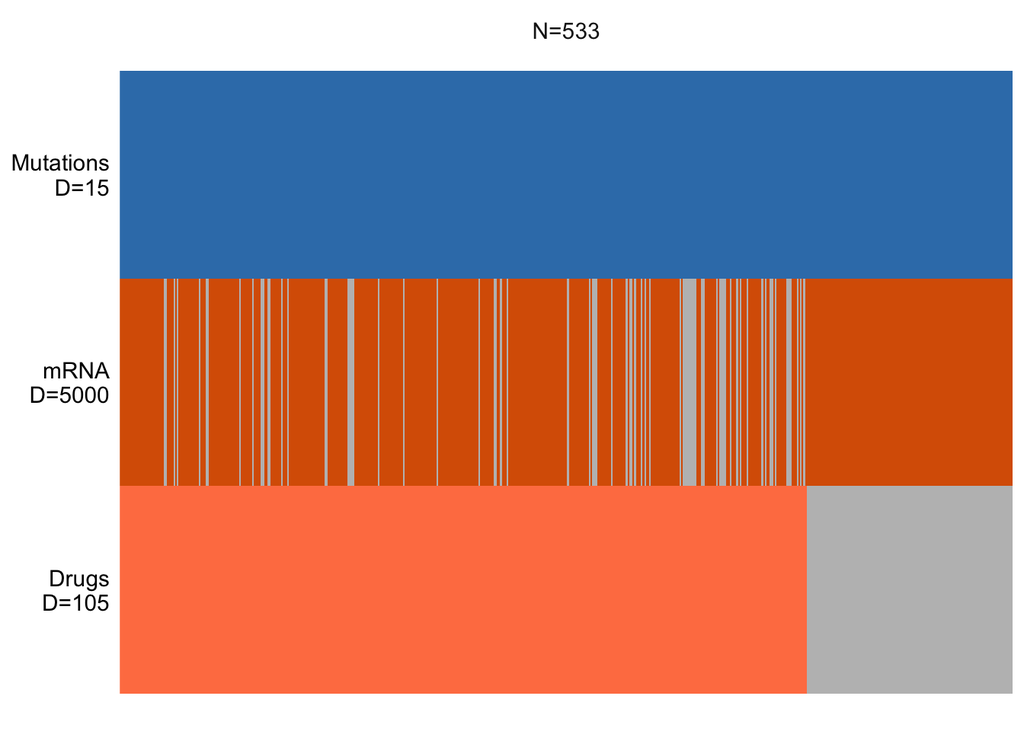

```r
plot_data_overview(MOFAobject)
```

## Define MOFA options

### Data options

```r
data_opts <- get_default_data_options(MOFAobject)
data_opts
```

```
$scale_views
[1] FALSE

$scale_groups
[1] FALSE

$center_groups
[1] TRUE

$use_float32
[1] FALSE

$views
[1] "Drugs"     "mRNA"      "Mutations"

$groups
[1] "single_group"
```

### Model options

```r
model_opts <- get_default_model_options(MOFAobject)
model_opts$num_factors <- 20

model_opts
```

```
$likelihoods
     Drugs       mRNA  Mutations
"gaussian" "gaussian" "gaussian"

$num_factors
[1] 20

$spikeslab_factors
[1] FALSE

$spikeslab_weights
[1] TRUE

$ard_factors
[1] FALSE

$ard_weights
[1] TRUE
```

Change the likelihood of Mutations to “bernoulli”

```r
model_opts$likelihoods[["Mutations"]] <- "bernoulli"
model_opts$likelihoods
```

```
      Drugs        mRNA   Mutations
 "gaussian"  "gaussian" "bernoulli"
```

### Training options

```r
train_opts <- get_default_training_options(MOFAobject)
train_opts$convergence_mode <- "fast"
train_opts$seed <- 2024

train_opts
```

```
$maxiter
[1] 1000

$convergence_mode
[1] "fast"

$drop_factor_threshold
[1] -1

$verbose
[1] FALSE

$startELBO
[1] 1

$freqELBO
[1] 5

$stochastic
[1] FALSE

$gpu_mode
[1] FALSE

$seed
[1] 2024

$outfile
NULL

$weight_views
[1] FALSE

$save_interrupted
[1] FALSE
```

## Train the MOFA model

Prepare MOFA object

```r
MOFAobject <- prepare_mofa(MOFAobject,
  data_options = data_opts,
  model_options = model_opts,
  training_options = train_opts
)
```

```
Checking data options...
```

```
Checking training options...
```

```
Checking model options...
```

Training

```r
MOFAobject <- run_mofa(MOFAobject, use_basilisk = TRUE)
```

```
Connecting to the mofapy2 package using basilisk.
    Set 'use_basilisk' to FALSE if you prefer to manually set the python binary using 'reticulate'.
```

## Visualising MOFA training results

### Factor correlation matrix

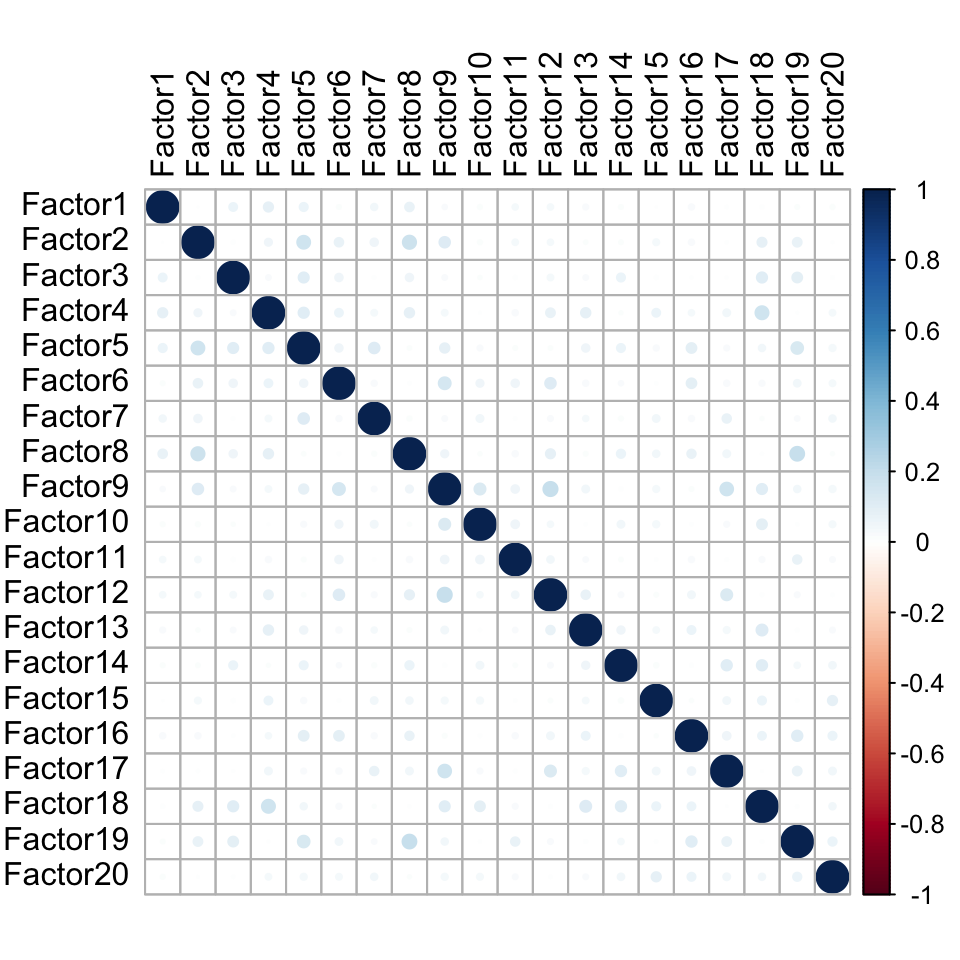

```r
plot_factor_cor(MOFAobject)
```

**MOFA factors are largely orthogonal to each other**

### Variance explained for each view by each factor

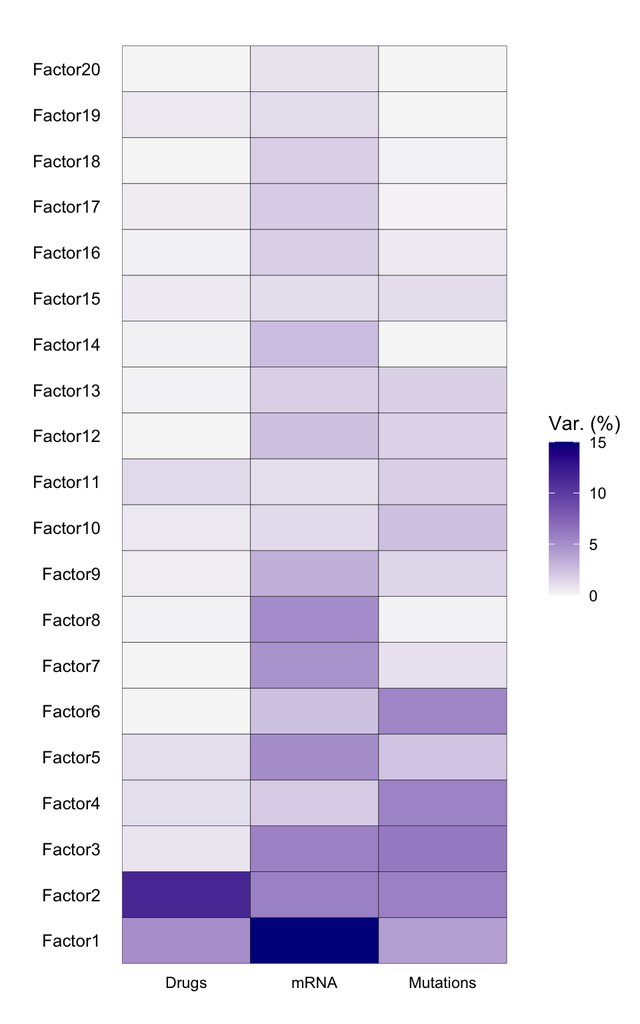

```r
plot_variance_explained(MOFAobject, max_r2=15)
```

### Total variance explained for each view by all factors

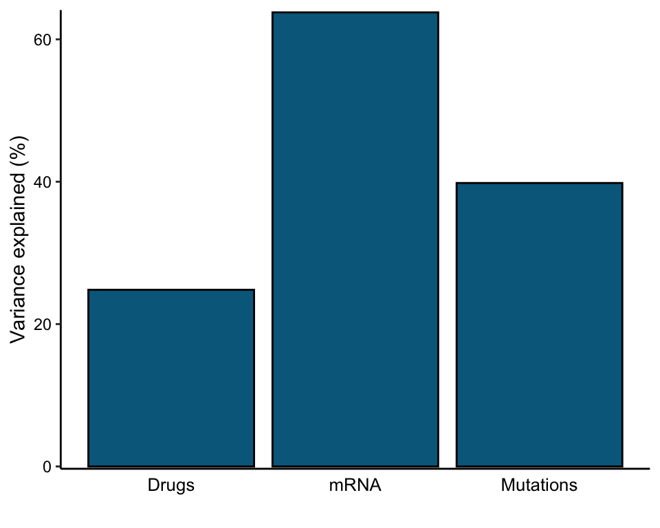

```r
plot_variance_explained(MOFAobject, plot_total = T)[[2]]
```

### Explore the biological meaning behind factor 1

#### Factor 1 values

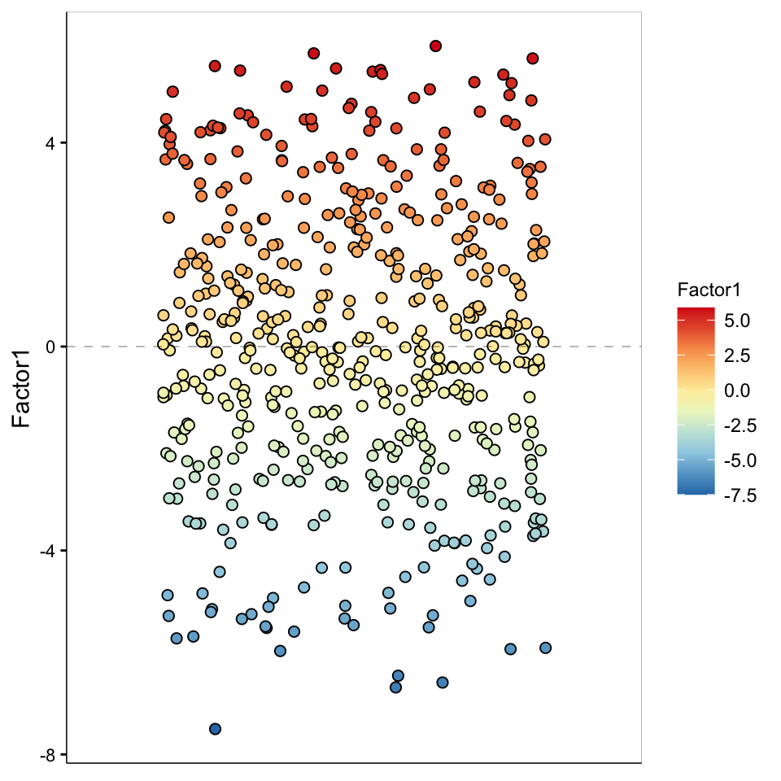

```r
plot_factor(MOFAobject,
  factors = 1,
  color_by = "Factor1"
)
```

#### Weight of genomic features on LF1

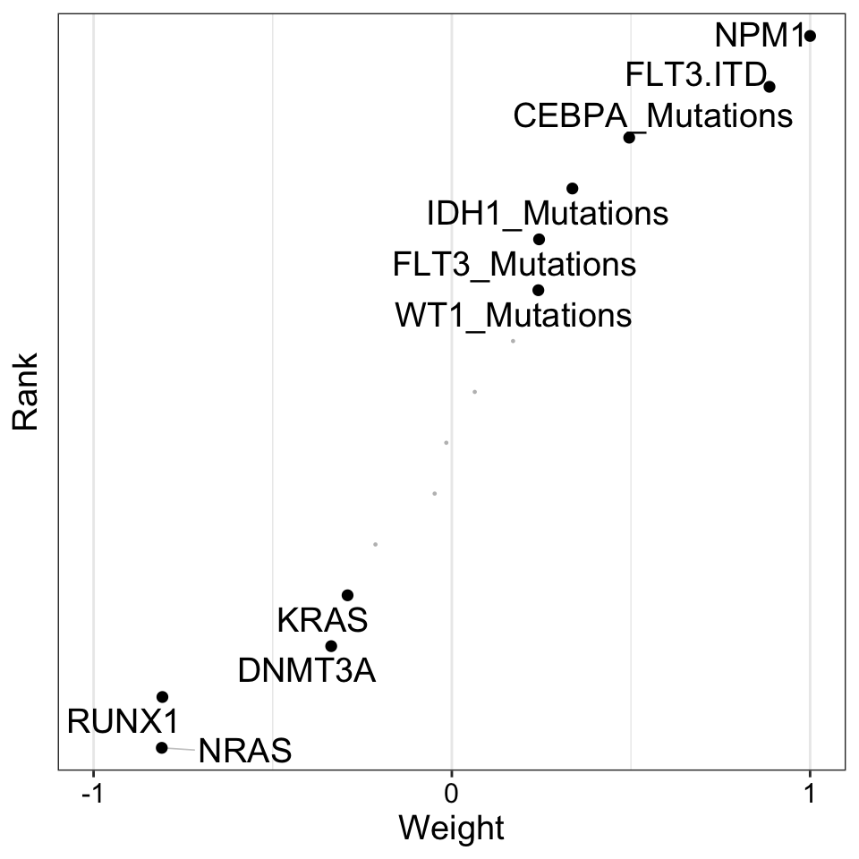

```r
plot_weights(MOFAobject,
 view = "Mutations",
 factor = 1,
 nfeatures = 10,     # Top number of features to highlight
 scale = T           # Scale weights from -1 to 1
)
```

LF1 is associated with some driver mutations in AML, including NPM1 and FLT3.ITD

#### Weight of genomic features on LF1 (just another way of visualisation)

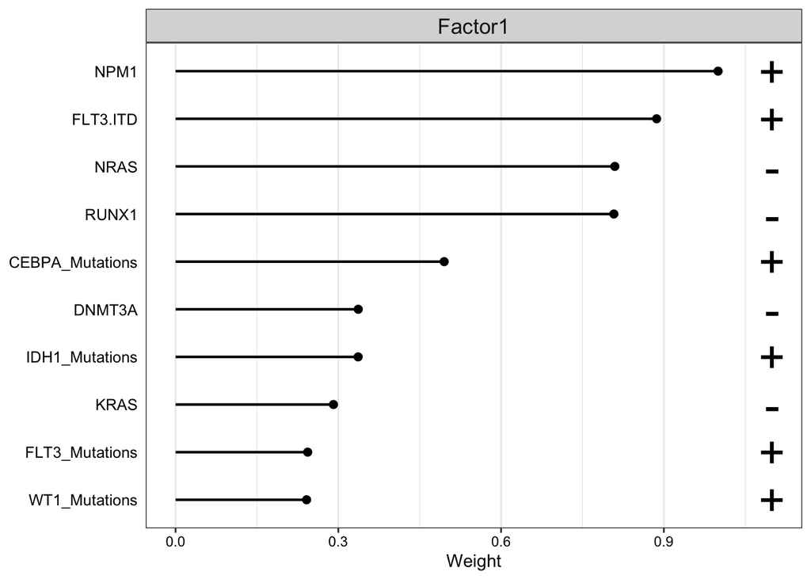

```r
plot_top_weights(MOFAobject,
 view = "Mutations",
 factor = 1,
 nfeatures = 10,     # Top number of features to highlight
 scale = T           # Scale weights from -1 to 1
)
```

### LF1 values versus NPM1 mutation

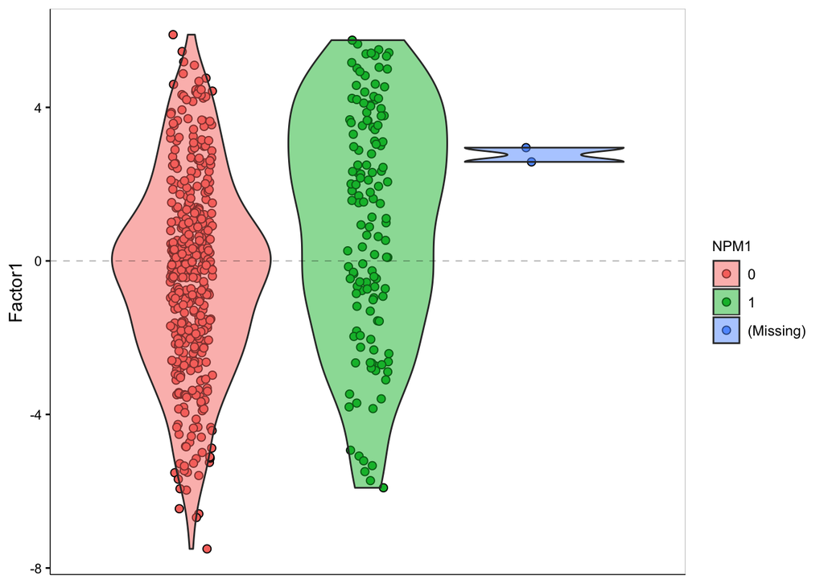

```r
plot_factor(MOFAobject,
  factors = 1,
  color_by = "NPM1",
  add_violin = TRUE,
  dodge = TRUE
)
```

[figure not shown]

```r
plot_factor(MOFAobject,
  factors = 1,
  color_by = "FLT3.ITD",
  add_violin = TRUE,
  dodge = TRUE
)
```

**Can you use the similar procedure to explore other factors you find interesting? What do you find? Feel free to communicate your findings with the trainers**